# CAP5638 Final Project: Remote sensing image classification with Convolution Neural Network

Feilin Lai

December 13, 2017

# I. Introduction

Remote sensing images contain abundant information about the earth surface, and it is a common practice to apply digital classification techniques to satellite images to explore the area covered by the images. Remote sensors capture the reflectance of ground at multiple spectral bands, each image band consists of a matrix of pixels that representing the spatial unit on the ground. Traditional remote sensing classification algorithms are mostly based on pixel, which is limited by inter-class spectral confusion, therefore spectral information alone cannot satisfy the desire of high classification accuracy. This issue might be addressed by the Convolution Neural Network (CNN) that takes a neighborhood of each pixel as input samples. According to Tobler’s First Law of geography that near things are more similar than distant things, using the neighborhood as classification samples can generate more consistent results by using both spatial relationship within pixels and spectral information in the classification process.To explore the effectiveness of CNN in Land Cover classification, an experiment is conducted over a heterogenous urban area.

# II. Study Area

The study area for this study locates at the city of Rio de Janeiro, Brazil. It is featured by complex urban features. Differentiating informal built-up lands from formal built-up lands based on remote sensing images is challenging due to their similarity in spectral response.

```r
# Overlay the study area boundary in the interactive GoogleMap GUI
suppressMessages(library(leaflet))
suppressMessages(library(ggmap))
LL = ggmap::geocode("Rio de Janeiro")
leaflet() %>%
  addTiles() %>%
  setView(LL[1, 1], LL[1, 2], zoom = 9) %>%
  addPolygons(data = RJ.shp)
```

[interactive chart not shown]

# III. Data: Landsat 8 OLI Image

The study area is fully covered by a single shot of Path 217, Row 76 along the Landsat 8 track, and one scene captured on Jan 31, 2016 was downloaded. The data is processed and stored in Level-1T precision by the USGS EROS Data Center.It has been radiometrically calibrated and atmospheric corrected in the former research project. Import the preprocessed image and plot it.

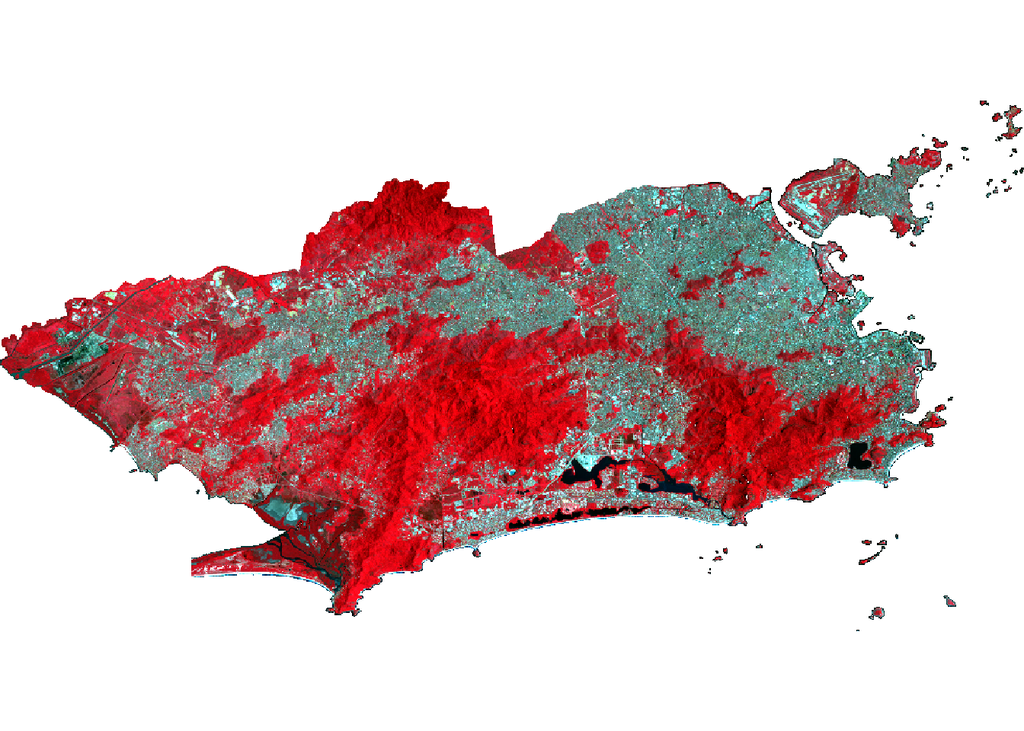

```r
# Plot False Color Combinaton (Near Infrared, Red, Green, max pixel value, linear stretch visual effect)
plotRGB(RJ.oli, r = 5, g = 4, b = 3, scale=65535,stretch="lin")
```

# IV. Classification scheme

There are 6 target classification classes, some of them have subclasses. The classification can either be done by training 6 classes, or training 12 subclasses then combining them into 6 target classes in the end.

```r
trainp<-read.csv("train_points.csv", header = TRUE,stringsAsFactor=FALSE)
testp <-read.csv("test_points.csv",  header = TRUE,stringsAsFactor=FALSE)
# Sub training classes label
label.subtrain = c(rep(1.1,105),rep(1.2,173),rep(1.3,152),
                   rep(1.4,17), rep(1.5,252),                 # 1 Formal Built-up Land (5 subclasses)
                   rep(2,194),                                # 2 Informal Built-up Land
                   rep(3.1,35), rep(3.2,141),rep(3.3,23),     # 3 Barren Land (3 subclasses)
                   rep(4,165),                                # 4 Forest Land
                   rep(5,114),                                # 5 Grassland and crop land
                   rep(6,113))                                # 6 Waters
class = c("Formal","Informal","Barren","Forest","Grassland","Waters")
ntrain= c(699,194,199,165,114,113)
ntest = c(160,100,50,120,100,50)
# Training labels
label.train=c(rep(1:6, ntrain))
label.train.text = c(rep(class,ntrain))
# Test labels
label.test = rep(1:6,ntest)
label.test.text = rep(class,ntest)
# Table of Classes
data.frame(class=class,train.size=ntrain, test.size=ntest)
```

```
##       class train.size test.size
## 1    Formal        699       160
## 2  Informal        194       100
## 3    Barren        199        50
## 4    Forest        165       120
## 5 Grassland        114       100
## 6    Waters        113        50
```

# V. Training and testing samples

The loaded samples are based on pixels, their file coordinates, map coordinates, and geographic coordinates (long/lat) are all included in a cvs file exported from the remote sensing software I used in the former study. Plot the location of samples on the image.

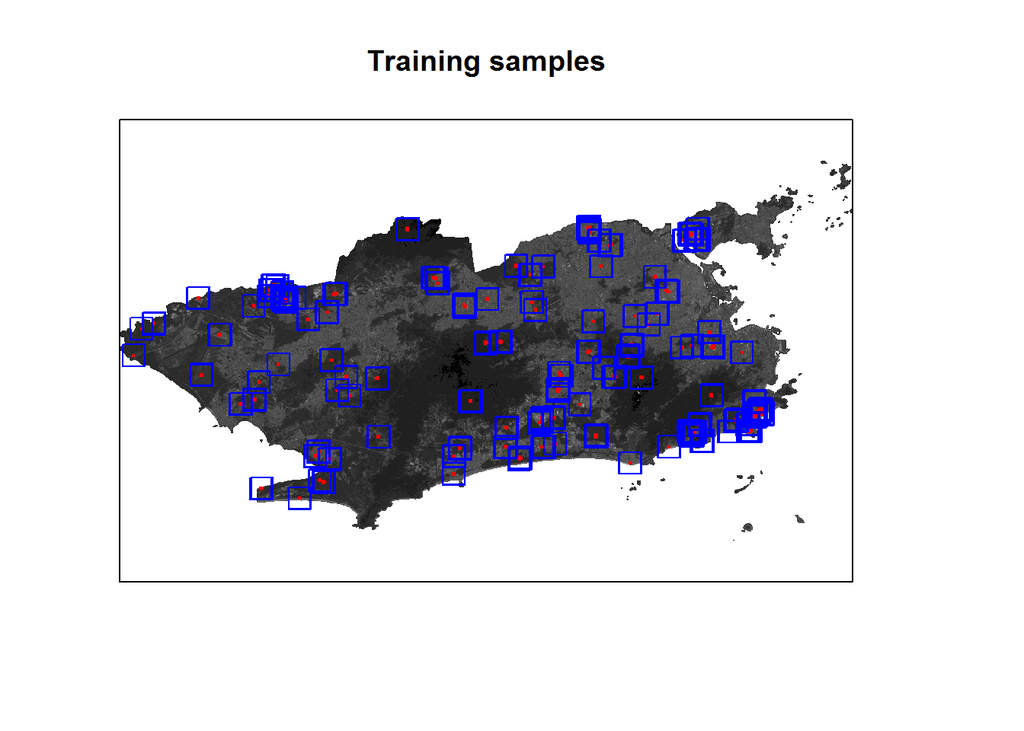

```r
# create a grayscale color palette to use for the image.
grayscale_colors <- gray.colors(100,            # number of different color levels
                                start = 0.0,    # how black (0) to go
                                end = 1.0,      # how white (1) to go
                                gamma = 2.2,    # correction between how a digital
                                # camera sees the world and how human eyes see it
                                alpha = NULL)   #Null=colors are not transparent
# Plot training samples
plot(RJ.oli[[1]], col=grayscale_colors, axes=FALSE,main="Training samples", legend=FALSE)
# plot location of each training sample
points(trainp$Map.X,trainp$Map.Y, pch=19, cex=.3, col = 2)
# plot square around the centroid
points(trainp$Map.X,trainp$Map.Y, pch=0, cex = 2, col = "blue" )
```

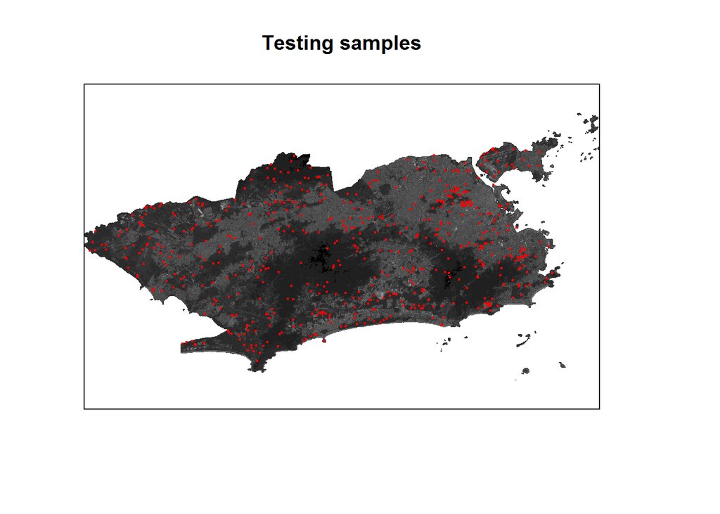

```r
# Plot test samples
plot(RJ.oli[[1]], col=grayscale_colors, axes=FALSE,main="Testing samples", legend=FALSE)
points(testp$Map.X,testp$Map.Y, pch=19, cex=.3, col = 2)
```

# VI. Methodology

## 1. Resampling the training and testing sample with a window

Extract 3x3 window based on the samples for the input of CNN, the size of individual input node will be 3x3x7, there are 1484 training inputs and 580 testing inputs.

```r
crd<-trainp[3:4]
tcrd<-testp[3:4]
# Ensemble vectors extracted from (3x3x7) to individual insance (label+63 features)
arrange<-function(coordinate,win.size){
  data=c(0)
  s=win.size*win.size
  for (i in 1:(nrow(coordinate)/s)){
    ins=var=i
    for(j in 1:s){
      var<-coordinate[(i-1)*s+j,]
      ins<-c(ins,var)
    }
    data<-rbind(data,ins)
  }
  return (data[-1,])
}

# Extract window values from the raster, re-arrange the input features
win.sampling<-function(image, coordinate, win.size){
  win=w=c(0)
  r=floor(win.size/2) # radius from the centroid of the sample
  for (i in 1:nrow(coordinate)){
    x=coordinate[i,1]
    y=coordinate[i,2]
    w<-cbind(seq(x-r*30,x+r*30,30),
             rep(seq(y-r*30,y+r*30,30),each=win.size)) # set up location of the pixel in a 3x3 grid
    win<-rbind(win,w)                                  # append to the temporary coordinate list
  }
  temp<-extract(image,win[-1,])                        # Get image value using temporary coordinates
  win.sample<-arrange(temp,win.size)
  return(win.sample)
}
train.win3<-win.sampling(RJ.oli,crd,3)
test.win3 <-win.sampling(RJ.oli,tcrd,3)
```

Examine some training samples by class (also by bands)

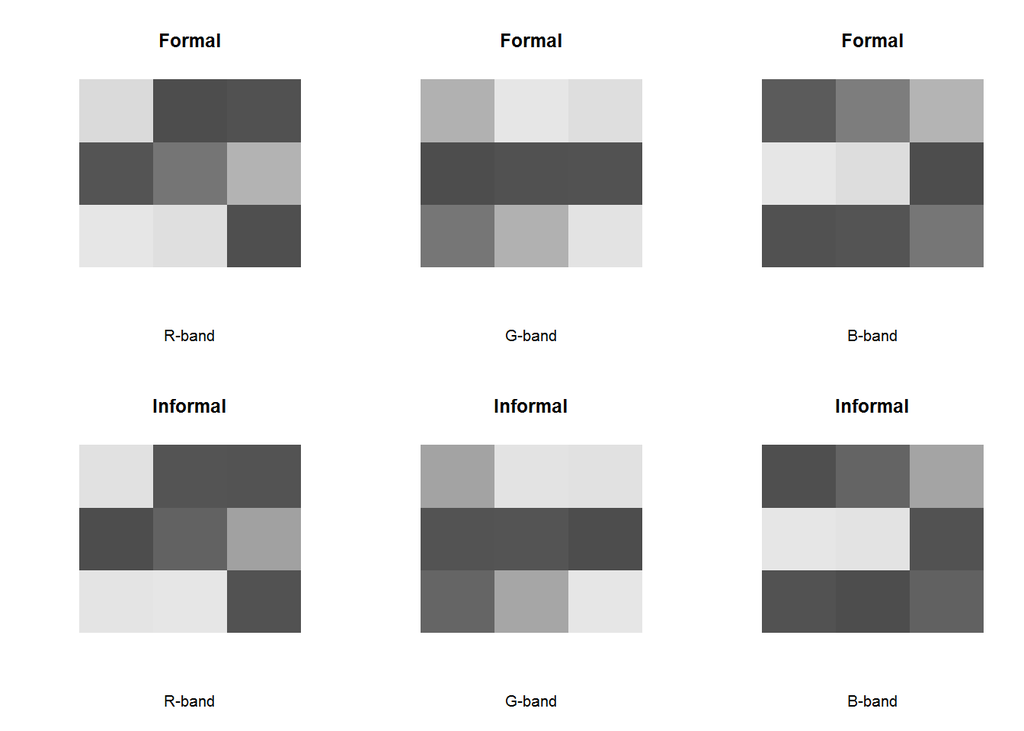

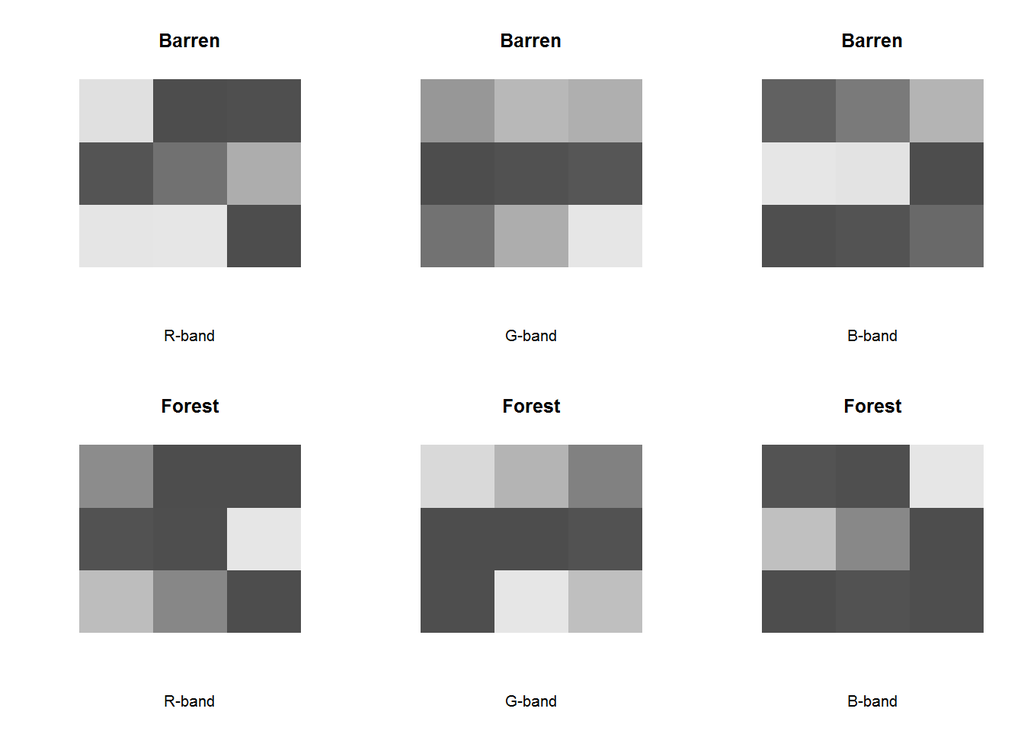

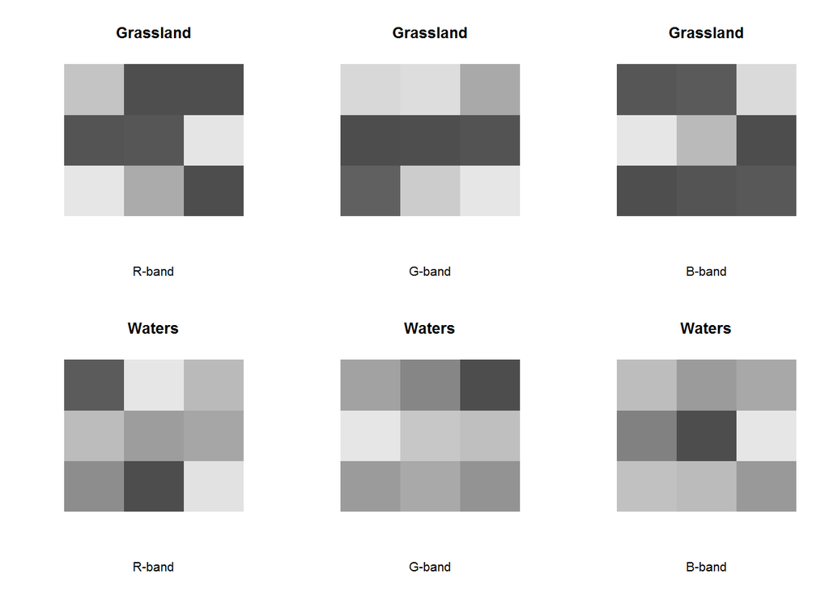

```r
train<-as.data.frame(train.win3)
test <-as.data.frame(test.win3)
names(train)<-as.vector(0:63)
names(test) <-as.vector(0:63)

# Plot some of image samples, 3x3 features
par(mfrow=c(2,3))
lapply(c(1,700,895,1095,1280,1395),
       function(x) {
         r1 <- r2 <- r3 <- raster(nrow=3, ncol=3)
         values(r1)<-as.integer(train[x,11:19])
         values(r2)<-as.integer(train[x,20:28])
         values(r3)<-as.integer(train[x,29:37])
         image(r3,col=gray.colors(255),axes=FALSE, xlab="R-band", ylab="",main=label.train.text[x])
         image(r2,col=gray.colors(255),axes=FALSE, xlab="G-band", ylab="",main=label.train.text[x])
         image(r1,col=gray.colors(255),axes=FALSE, xlab="B-band", ylab="",main=label.train.text[x])
         }
)
```

## 2. CNN with h2o package

h2o is an open source math engine for big data that computes parallel distributed machine learning algorithms such as generalized linear models, gradient boosting machines, random forests, and neural networks (deep learning) within various cluster environments.

### 2.1 Initial h2o process, Use h2o package, and load the training and testing datasets and convert the label to digit factor

```r
suppressMessages(library(h2o))
#start a local h2o cluster
local.h2o <- h2o.init(ip = "localhost", port = 54321, startH2O = TRUE, nthreads=-1)
```

[output not shown]

### 2.2 Train the model by 6 classes using 3x3 window size

```r
# convert digit labels to factor for classification
train[,1]<-label.train.text
train[,1]<-as.factor(train[,1])

# pass dataframe from inside of the R environment to the H2O instance
trData<-as.h2o(train)
# Next is to train the model. For this experiment, default setting of 200 layers of 200 nodes each are used. The activation function used is Tanh, cross-entropy was used as the loss function and number of epochs is 20
LC.dl <- h2o.deeplearning(x = 2:64,             # window of inputs 63(3x3x7)
                          y = 1,                # training labels
                          trData,               # h2o data
                          activation = "Tanh",  # activation function
                          loss="CrossEntropy",  # Loss function
                          epochs = 50)          # epochs
# Model accuracy
h2o.confusionMatrix(LC.dl)
```

```
## Confusion Matrix: Row labels: Actual class; Column labels: Predicted class
##           Barren Forest Formal Grassland Informal Waters  Error
## Barren       134      0     64         1        0      0 0.3266
## Forest         0    165      0         0        0      0 0.0000
## Formal         0      0    563         0      136      0 0.1946
## Grassland      0      9      0       102        3      0 0.1053
## Informal       0      0     14         0      180      0 0.0722
## Waters         1      0      0         0        0    112 0.0088
## Totals       135    174    641       103      319    112 0.1536
##                    Rate
## Barren    =    65 / 199
## Forest    =     0 / 165
## Formal    =   136 / 699
## Grassland =    12 / 114
## Informal  =    14 / 194
## Waters    =     1 / 113
## Totals    = 228 / 1,484
```

```r
# Predict the test data
test_h2o<-as.h2o(test[-1])
pred.dl.test<-h2o.predict(object=LC.dl, newdata=test_h2o)
# convert H2O format into data frame and save as csv
df.test <- as.data.frame(pred.dl.test)

# Confusion Matrix
suppressMessages(library(caret))
confusionMatrix(df.test$predict,label.test.text)
```

```
## Confusion Matrix and Statistics
##
##            Reference
## Prediction  Barren Forest Formal Grassland Informal Waters
##   Barren         2      0      0         0        0      3
##   Forest         3    111      2        54        3      6
##   Formal        14      0     58         0        6      4
##   Grassland     17      3      2        28        0      0
##   Informal      13      5     98        18       91      0
##   Waters         1      1      0         0        0     37
##
## Overall Statistics
##
##                Accuracy : 0.5638
##                  95% CI : (0.5223, 0.6046)
##     No Information Rate : 0.2759
##     P-Value [Acc > NIR] : < 2.2e-16
##
##                   Kappa : 0.4607
##  Mcnemar's Test P-Value : NA
##
## Statistics by Class:
##
##                      Class: Barren Class: Forest Class: Formal
## Sensitivity               0.040000        0.9250        0.3625
## Specificity               0.994340        0.8522        0.9429
## Pos Pred Value            0.400000        0.6201        0.7073
## Neg Pred Value            0.916522        0.9776        0.7952
## Prevalence                0.086207        0.2069        0.2759
## Detection Rate            0.003448        0.1914        0.1000
## Detection Prevalence      0.008621        0.3086        0.1414
## Balanced Accuracy         0.517170        0.8886        0.6527
##                      Class: Grassland Class: Informal Class: Waters
## Sensitivity                   0.28000          0.9100       0.74000
## Specificity                   0.95417          0.7208       0.99623
## Pos Pred Value                0.56000          0.4044       0.94872
## Neg Pred Value                0.86415          0.9746       0.97597
## Prevalence                    0.17241          0.1724       0.08621
## Detection Rate                0.04828          0.1569       0.06379
## Detection Prevalence          0.08621          0.3879       0.06724
## Balanced Accuracy             0.61708          0.8154       0.86811
```

### 2.3 Train the model with 12 subclasses, then merge the results

```r
# convert digit labels to factor for classification
train[,1]<-label.subtrain
train[,1]<-as.factor(train[,1])

# pass dataframe from inside of the R environment to the H2O instance
trData<-as.h2o(train)
# Next is to train the model. For this experiment, default setting of 200 layers of 200 nodes each are used. The activation function used is Tanh and number of epochs is 20
LC.sub.dl <- h2o.deeplearning(x = 2:64, y = 1, trData, activation = "Tanh",
                              loss="CrossEntropy",epochs = 50)
# Model accuracy
h2o.confusionMatrix(LC.sub.dl)
```

```
## Confusion Matrix: Row labels: Actual class; Column labels: Predicted class
##        1.1 1.2 1.3 1.4 1.5   2 3.1 3.2 3.3   4  5 6  Error          Rate
## 1.1    104   0   0   0   1   0   0   0   0   0  0 0 0.0095 =     1 / 105
## 1.2      0 173   0   0   0   0   0   0   0   0  0 0 0.0000 =     0 / 173
## 1.3      3   0  44   0  64  41   0   0   0   0  0 0 0.7105 =   108 / 152
## 1.4      0   0   0  17   0   0   0   0   0   0  0 0 0.0000 =      0 / 17
## 1.5     41   0   3   0 145  63   0   0   0   0  0 0 0.4246 =   107 / 252
## 2        1   0   0   0   1 192   0   0   0   0  0 0 0.0103 =     2 / 194
## 3.1      0   0   0   0   0   0  35   0   0   0  0 0 0.0000 =      0 / 35
## 3.2      0   0   0   0   0   0   0 141   0   0  0 0 0.0000 =     0 / 141
## 3.3     21   0   0   0   0   0   0   0   2   0  0 0 0.9130 =     21 / 23
## 4        0   0   0   0   0   0   0   0   0 165  0 0 0.0000 =     0 / 165
## 5        0   0   0   0   0   0   0   0   0  42 72 0 0.3684 =    42 / 114
## 6      113   0   0   0   0   0   0   0   0   0  0 0 1.0000 =   113 / 113
## Totals 283 173  47  17 211 296  35 141   2 207 72 0 0.2655 = 394 / 1,484
```

```r
#Predict the test data
test_h2o<-as.h2o(test[-1])
pred.dl.test<-h2o.predict(object=LC.sub.dl, newdata=test_h2o)
# convert H2O format into data frame and save as csv
df.test <- as.data.frame(pred.dl.test)

# Confusion Matrix
prediction<-floor(as.numeric(levels(df.test$predict))[df.test$predict])
confusionMatrix(prediction,label.test)
```

```
## Confusion Matrix and Statistics
##
##           Reference
## Prediction   1   2   3   4   5   6
##          1  68   2  18   1   0  43
##          2  81  96   4   4   3   0
##          3   0   0   5   0   0   0
##          4   4   2   9 115  79   6
##          5   7   0  14   0  18   0
##          6   0   0   0   0   0   1
##
## Overall Statistics
##
##                Accuracy : 0.5224
##                  95% CI : (0.4809, 0.5637)
##     No Information Rate : 0.2759
##     P-Value [Acc > NIR] : < 2.2e-16
##
##                   Kappa : 0.3971
##  Mcnemar's Test P-Value : NA
##
## Statistics by Class:
##
##                      Class: 1 Class: 2 Class: 3 Class: 4 Class: 5 Class: 6
## Sensitivity            0.4250   0.9600 0.100000   0.9583  0.18000 0.020000
## Specificity            0.8476   0.8083 1.000000   0.7826  0.95625 1.000000
## Pos Pred Value         0.5152   0.5106 1.000000   0.5349  0.46154 1.000000
## Neg Pred Value         0.7946   0.9898 0.921739   0.9863  0.84843 0.915371
## Prevalence             0.2759   0.1724 0.086207   0.2069  0.17241 0.086207
## Detection Rate         0.1172   0.1655 0.008621   0.1983  0.03103 0.001724
## Detection Prevalence   0.2276   0.3241 0.008621   0.3707  0.06724 0.001724
## Balanced Accuracy      0.6363   0.8842 0.550000   0.8705  0.56812 0.510000
```